# Manner of Excercise Prediction

Ulrich v. Staden

23/09/2021

## Executive Summary

The data for this project was provided by the following link: http://web.archive.org/web/20161224072740/http:/groupware.les.inf.puc-rio.br/har The Data given to be analised contians a total of a 161 variables and over 19000 obsevations, this indicates that the data size was quite large. The Data contains measurements from 4 different accelerometers based on the belt, arm, dumbell and forearm. These accelerometers measured values between 6 diffferent people on different time stamps.

There are 5 different levels (A,B,C,D,E) describing the way of use of the 4 different excersises, under the variable called ‘classe’. This classe variable was the outcome of each observation and the rest of the variables were the predictors.

Based on the analysis and the results obtained within this report, the following table presents the accuracy and out of sample errors for the 3 different methods used.

[output not shown]

The best solution according to the table was the Random Forest approach and therefor further used to predict the test cases given.

## Analysis and Design

### Environemnt Setup

#### Libraries

The following libraries were added for this project to be able to train, validate and predict data. The last 2 libraries added supports and enables the system to do multiprocessing during training to increase the speed of the training process.

```r
library(e1071)
library(forecast)
library(caret)
library(parallel)
library(doParallel)
```

#### Setup Multprocessing

```r
cluster <- makeCluster(detectCores() - 1)
registerDoParallel(cluster)
```

#### Set Seed and Load data

```r
# Set Seed
set.seed(1234)

# Load Data
Data <- read.csv("https://d396qusza40orc.cloudfront.net/predmachlearn/pml-training.csv")
TestCases <- read.csv("https://d396qusza40orc.cloudfront.net/predmachlearn/pml-testing.csv")
```

A seed were set for reproducibility of the results within this report. There are 2 data sources acquired, first the actual data to be used for training, validation and testing and the second data source provides 20 specific observations or cases on which the final model should be used to predict their outcome.

### Preprocessing

The following code removed unwanted and unnecessary variables from the data.

```r
# Remove specific columns from loaded data.
Data <- Data[,-c(1,3,4,5)]
# Remove all columns containing an NA value.
Data <- Data[, colSums(is.na(Data)) == 0]
# Remove all columns with very little or zero variance.
Data <- Data[,-nearZeroVar(Data)]
```

### Slicing Data

```r
Partition <- createDataPartition(y = Data$classe,p = 0.80,list = FALSE)

Training <- data.frame( Data[Partition,])
Testing <- data.frame(Data[-Partition,])
```

The data obtained were sliced into 80% random observations of the data for training and validation purposes and 20% for testing.

### Set Validation

```r
# Set Train Control for Cross validation
trainC <- trainControl(method = "cv", number = 5, allowParallel = T)
```

Setting Validation up for cross validation with a K fold of 5 instead of 10, because of the large amount of observations that exist.

### Training and Cross Validation Results

Three different models were attempted and cross validated to determine the best model for the solution.

#### Random Forest Method

```r
modFit_rf <- train(classe~.,method = "rf",data = Training, trControl = trainC)
modFit_rf
```

```
## Random Forest
##
## 15699 samples
##    54 predictor
##     5 classes: 'A', 'B', 'C', 'D', 'E'
##
## No pre-processing
## Resampling: Cross-Validated (5 fold)
## Summary of sample sizes: 12560, 12559, 12558, 12558, 12561
## Resampling results across tuning parameters:
##
##   mtry  Accuracy   Kappa
##    2    0.9940122  0.9924255
##   30    0.9975159  0.9968579
##   58    0.9940761  0.9925068
##
## Accuracy was used to select the optimal model using the largest value.
## The final value used for the model was mtry = 30.
```

#### Gradient Boosting Method

```r
modFit_gbm <- train(classe~.,method = "gbm" ,data = Training, trControl = trainC,verbose = FALSE)
modFit_gbm
```

```
## Stochastic Gradient Boosting
##
## 15699 samples
##    54 predictor
##     5 classes: 'A', 'B', 'C', 'D', 'E'
##
## No pre-processing
## Resampling: Cross-Validated (5 fold)
## Summary of sample sizes: 12560, 12558, 12560, 12559, 12559
## Resampling results across tuning parameters:
##
##   interaction.depth  n.trees  Accuracy   Kappa
##   1                   50      0.7606224  0.6962663
##   1                  100      0.8350225  0.7911666
##   1                  150      0.8733690  0.8397501
##   2                   50      0.8871276  0.8570559
##   2                  100      0.9413982  0.9258448
##   2                  150      0.9616543  0.9514803
##   3                   50      0.9336912  0.9160692
##   3                  100      0.9710810  0.9634113
##   3                  150      0.9873878  0.9840455
##
## Tuning parameter 'shrinkage' was held constant at a value of 0.1
##
## Tuning parameter 'n.minobsinnode' was held constant at a value of 10
## Accuracy was used to select the optimal model using the largest value.
## The final values used for the model were n.trees = 150, interaction.depth =
##  3, shrinkage = 0.1 and n.minobsinnode = 10.
```

#### Linear Discriminant Method

```r
modFit_lda <- train(classe~.,method = "lda" ,data = Training, trControl = trainC)
modFit_lda
```

```
## Linear Discriminant Analysis
##
## 15699 samples
##    54 predictor
##     5 classes: 'A', 'B', 'C', 'D', 'E'
##
## No pre-processing
## Resampling: Cross-Validated (5 fold)
## Summary of sample sizes: 12561, 12558, 12560, 12559, 12558
## Resampling results:
##
##   Accuracy  Kappa
##   0.747307  0.6799515
```

### Prediction and Accuracy

#### Random Forest Method

```r
predict_rf <- predict(modFit_rf,Testing)
confusionMatrix(predict_rf, as.factor(Testing$classe))$over
```

```
##       Accuracy          Kappa  AccuracyLower  AccuracyUpper   AccuracyNull
##      0.9974509      0.9967756      0.9953172      0.9987770      0.2844762
## AccuracyPValue  McnemarPValue
##      0.0000000            NaN
```

#### Gradient Boosting Method

```r
predict_gbm <- predict(modFit_gbm,Testing)
confusionMatrix(predict_gbm, as.factor(Testing$classe))$over
```

```
##       Accuracy          Kappa  AccuracyLower  AccuracyUpper   AccuracyNull
##      0.9862350      0.9825893      0.9820774      0.9896429      0.2844762
## AccuracyPValue  McnemarPValue
##      0.0000000            NaN
```

#### Linear Discriminant Method

```r
predict_lda <- predict(modFit_lda,Testing)
confusionMatrix(predict_lda, as.factor(Testing$classe))$over
```

```
##       Accuracy          Kappa  AccuracyLower  AccuracyUpper   AccuracyNull
##   7.392302e-01   6.698911e-01   7.251887e-01   7.529145e-01   2.844762e-01
## AccuracyPValue  McnemarPValue
##   0.000000e+00   5.668349e-39
```

### Predictions on the 20 Test Cases (Random Forest Method)

```r
predict(modFit_rf,TestCases)
```

```
##  [1] B A B A A E D B A A B C B A E E A B B B
## Levels: A B C D E
```

### Appendix

#### Random Forest

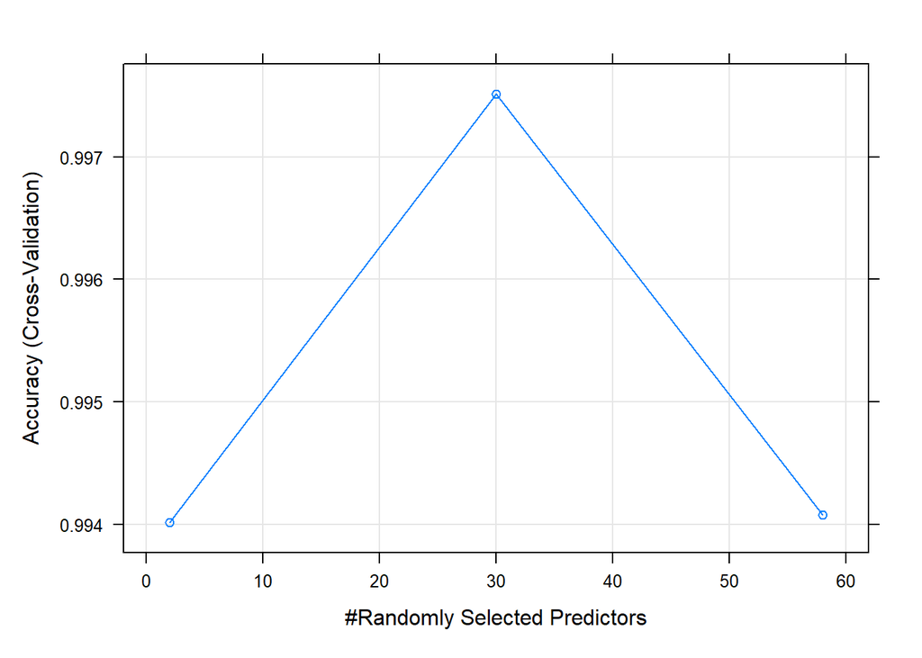

```r
plot(modFit_rf)
```

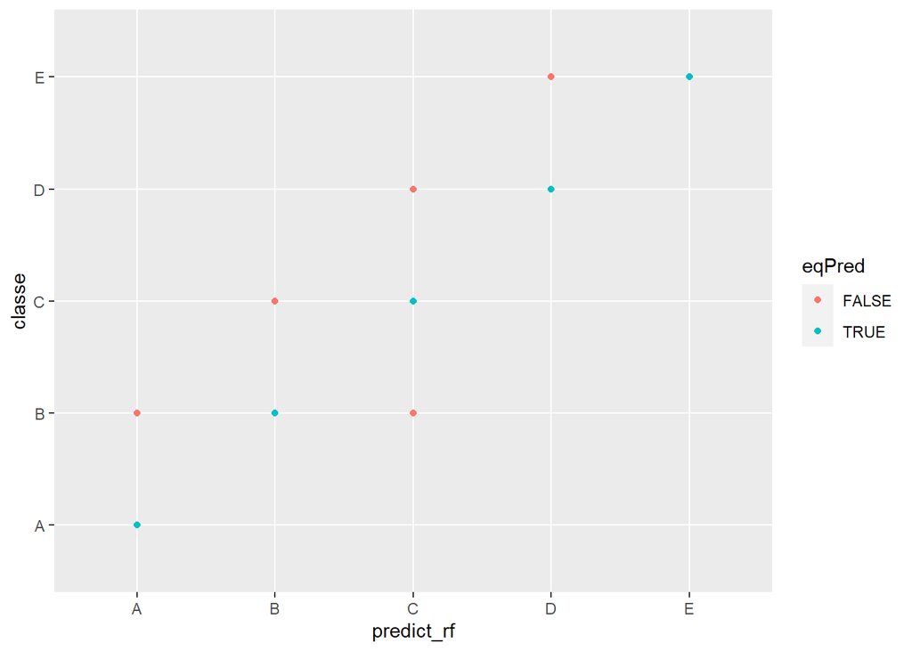

```r
eqPred <- (predict_rf==Testing$classe)
qplot(predict_rf,classe ,data = Testing,colour = eqPred)
```

#### Gradient Boosting Method

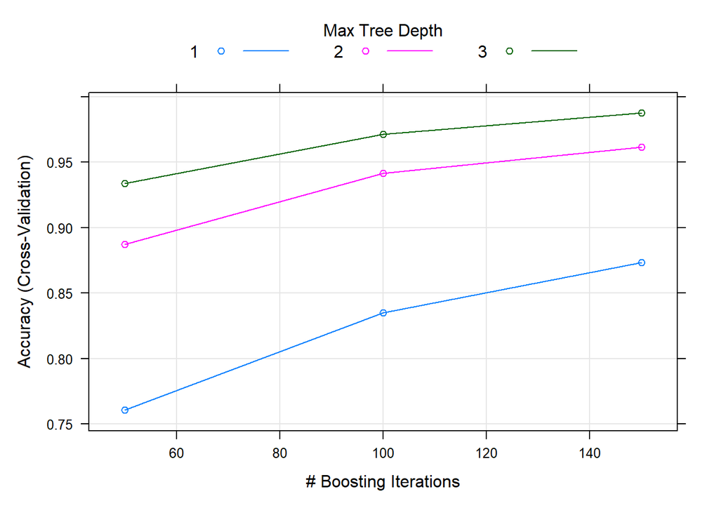

```r
plot(modFit_gbm)
```

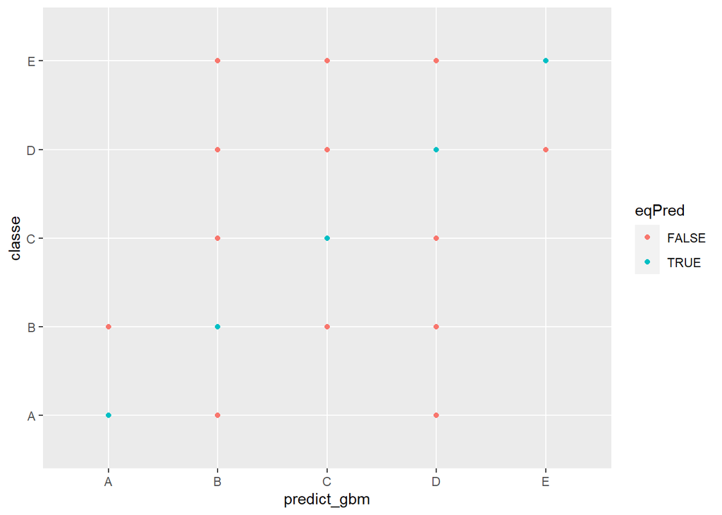

```r
eqPred <- (predict_gbm==Testing$classe)
qplot(predict_gbm,classe ,data = Testing,colour = eqPred)
```

#### Linear Discriminant Method

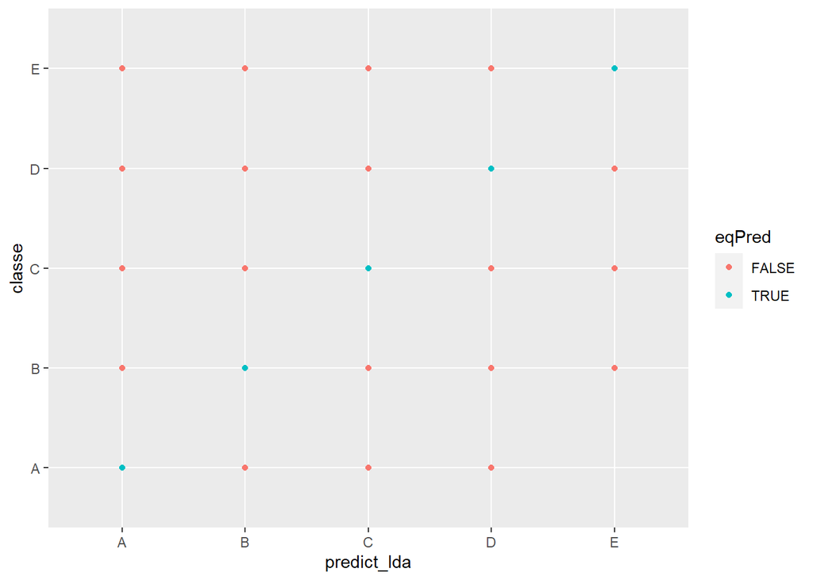

```r
eqPred <- (predict_lda==Testing$classe)
qplot(predict_lda,classe ,data = Testing,colour = eqPred)
```